# Text As Data: Assignment 2

Lena Wagner, 206246

30th of November 2021

## Load and prepare data

Load the `corpus_us_debate_speaker` from the data folder on the course’s github repository main site

### Load

```r
setwd("C:/Users/lena_/OneDrive/Desktop/MPP Hertie/21-22_Fall/TextAsData")

load("corpus_us_debate_speaker.rda")
summary(corpus_us_debate_speaker, n = 5)
```

```
## Corpus consisting of 23 documents, showing 5 documents:
##
##       Text Types Tokens Sentences party   speaker
##     ALLARD   400   1165        53     R    ALLARD
##       BOND   129    232         9     R      BOND
##      BOXER  2231  18527       886     D     BOXER
##  BROWNBACK   646   2884       168     R BROWNBACK
##    BUNNING   281    593        32     R   BUNNING
```

### Prepare: Convert to Paragraphs

reshape the corpus into paragraphs

```r
speeches_para <- corpus_reshape(corpus_us_debate_speaker, to = "paragraphs")
head(summary(speeches_para))
```

```
##       Text Types Tokens Sentences party speaker
## 1 ALLARD.1    32     48         3     R  ALLARD
## 2 ALLARD.2    41     64         4     R  ALLARD
## 3 ALLARD.3    25     29         1     R  ALLARD
## 4 ALLARD.4    22     24         1     R  ALLARD
## 5 ALLARD.5    68    144         3     R  ALLARD
## 6 ALLARD.6    55     89         3     R  ALLARD
```

### Subset & Convert df to dfm

Select only those paragraphs with at least 8 words in them. Create a tokens object in which words are converted to lower case and remove numbers, punctuation, common stop words, and tokens with less than two characters. Convert the tokens object to a dfm documents

```r
speeches_para <- corpus_subset(speeches_para, ntoken(speeches_para) > 7)

para_tokens <- tokens(speeches_para,
               remove_punct = TRUE,
               remove_numbers = TRUE) %>%
  tokens_remove(stopwords()) %>%
  tokens_select(min_nchar = 2) %>%
  tokens_tolower()

para_dfm <- dfm(para_tokens)
```

#### Convert dfm to stm

```r
para_stm <- convert(para_dfm, to = "stm")
```

## Identify optimal number of topics

Fit five different structural topic models with different numbers of topics for $K$ = 10, 20, 30, 40, 50 respectively.

```r
K <- c(10, 20, 30, 40, 50)

for (k in K) {
  stm <- stm(
    documents = para_stm$documents,
    vocab = para_stm$vocab,
    K = k,
    data = para_stm$meta
    )
  name <- paste0("stm_", k)
  assign(name, stm)
}
```

Create a diagnostic plot showing the held-out likelihood, the residuals, the semantic coherence of the topics, and the lower bound.

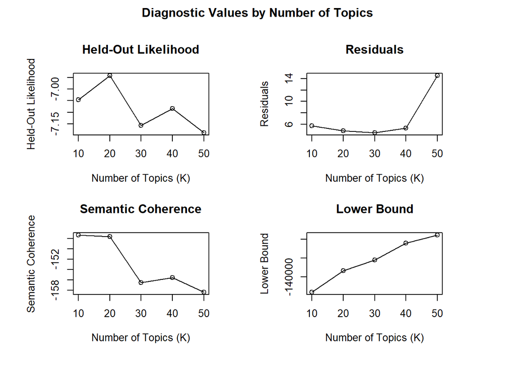

Also create a plot to contrast the semantic coherence with the exclusivity of the topics, i.e. how much each topic has its own vocabulary not used by other topics.

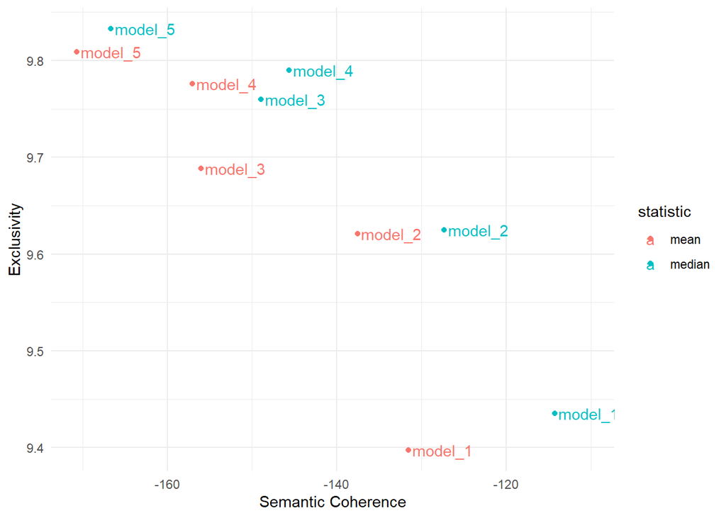

Topic models with fewer topics show higher semantic coherence, which is highest at the model with 10 topics and decreases up until the model with 30 topics, where it stays at a relatively constant level. A model is considered to be semantically coherent when the most likely terms under each topic frequently co-occur together within the same document. However, semantic coherence is said to be achieved relatively easily and always comes at a trade-off with topic exclusivity, i.e. the extent to which the most frequent terms of one topic do not appear as top terms in other topics. Hence models with higher coherence will shows less exclusivity. The second diagnostic plot shows that exclusivity is higher in models with more topics. An acceptable compromise can be found in the model with 20 and 30 topics. Considering that the model with 20 topics outperformed the one with 30 topics with regards to held-out likelihood, I will proceed with the model with 20 topics.

## Create topic labels and explore topic prevalence

### Word Probabilities

After you selected your preferred topic model, explore the word probabilities ($\beta$) and create meaningful labels for each topic. For some topics, identify documents that are very representative for those particular topics. Discuss what some of your topics are about in a bit more detail.

```r
#create words and labels for each topic (5 words per topic)
library("reshape2")
label_topics <- labelTopics(stm_20, n = 5)
terms <- label_topics$prob
topic_names <- apply(terms, 1, paste, collapse="_")
topicnum <- label_topics$topicnums
topic_names_df <- data.frame(topic_names = topic_names, topic = as.character(topicnum))
topic_names_df
```

```
##                                      topic_names topic
## 1             right_woman's_choose_woman_percent     1
## 2                  many_debate_know_procedure_go     2
## 3             baby_procedure_specific_baby's_can     3
## 4                    children_child_life_us_hand     4
## 5           fetus_dilation_body_living_technique     5
## 6          legislation_believe_birth_ban_partial     6
## 7        abortion_procedures_safe_used_induction     7
## 8     procedure_can_necessary_medically_american     8
## 9  medical_physicians_choice_patient_appropriate     9
## 10             senator_time_mr_president_minutes    10
## 11  abortion_life_procedure_partial-birth_mother    11
## 12    health_exception_women's_bill_reproductive    12
## 13             health_bill_woman_procedure_going    13
## 14     partial-birth_abortion_ban_procedure_vote    14
## 15              abortion_people_states_legal_law    15
## 16               roe_court_wade_supreme_decision    16
## 17                   baby_womb_surgery_see_child    17
## 18                  women_want_right_doctor_said    18
## 19                    child_baby_born_can_mother    19
## 20     health_evidence_necessary_procedure_never    20
```

```r
#explore word probabilities
wordprob_df <- tidy(stm_20, matrix = "beta") %>%
  group_by(topic) %>%
  slice_max(beta, n = 10) %>%
  ungroup() %>%
  arrange(topic, -beta)

head(wordprob_df)
```

```
## # A tibble: 6 x 3
##   topic term      beta
##   <int> <chr>    <dbl>
## 1     1 right   0.0757
## 2     1 woman's 0.0604
## 3     1 choose  0.0402
## 4     1 woman   0.0315
## 5     1 percent 0.0314
## 6     1 may     0.0192
```

Plot the word probabilities by topic

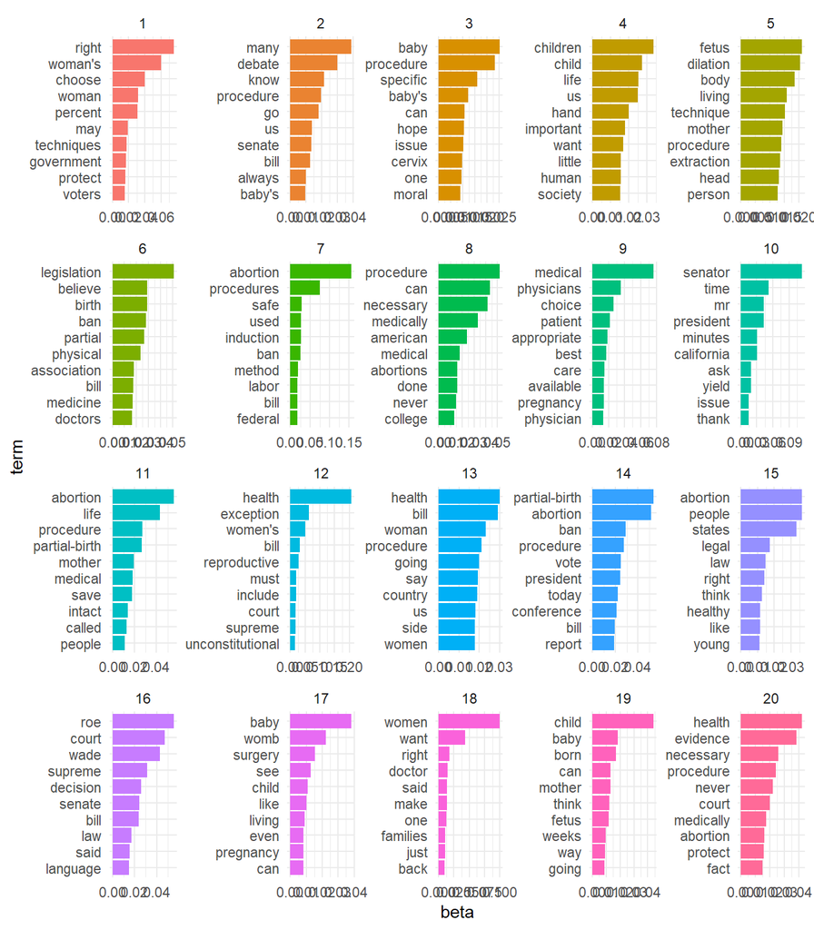

```r
#identify the three most representative documents for each topic
docdist_df <- tidy(stm_20, matrix = "theta") %>%
  merge(., topic_names_df, by = "topic") %>%
  group_by(topic) %>%
  top_n(3, gamma)

docdist_df
```

```
## # A tibble: 61 x 4
## # Groups:   topic [20]
##    topic document gamma topic_names
##    <int>    <int> <dbl> <chr>
##  1     1      962 0.876 right_woman's_choose_woman_percent
##  2     1      993 0.801 right_woman's_choose_woman_percent
##  3     1     1409 0.780 right_woman's_choose_woman_percent
##  4     2     1368 0.945 many_debate_know_procedure_go
##  5     2     1469 0.941 many_debate_know_procedure_go
##  6     2     1613 0.943 many_debate_know_procedure_go
##  7     3      845 0.955 baby_procedure_specific_baby's_can
##  8     3      885 0.976 baby_procedure_specific_baby's_can
##  9     3     1561 0.975 baby_procedure_specific_baby's_can
## 10     4      836 0.961 children_child_life_us_hand
## # ... with 51 more rows
```

```r
#find two most representative documents per topic
doc1 <- findThoughts(stm_20,
                     texts = speeches_para,
                     topic = 3,
                     n = 2)$docs[[1]]

doc4 <- findThoughts(stm_20,
                     texts = speeches_para,
                     topic = 4,
                     n = 2)$docs[[1]]

doc20 <- findThoughts(stm_20,
                      texts = speeches_para,
                      topic = 20,
                      n = 2)$docs[[1]]
```

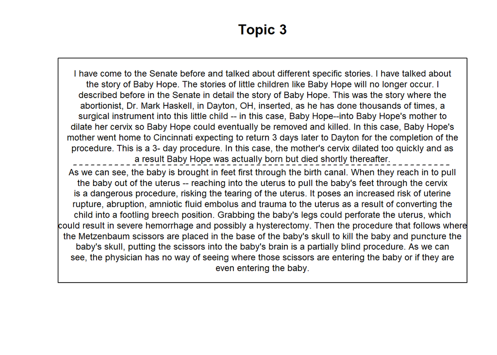

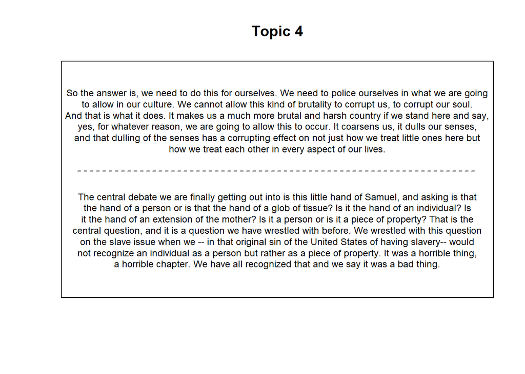

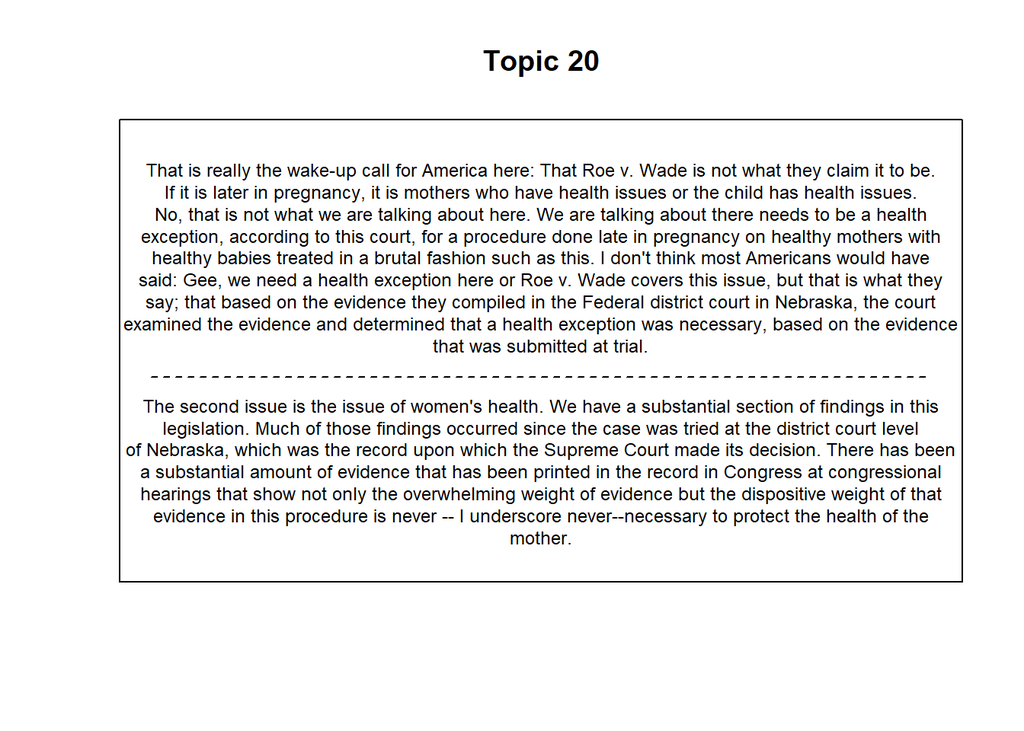

*Discussion:* The plots above show exemplary quotes from highly representative documents for topic 3, 4 and 20. The terms for topic 3, `baby_procedure_specific_baby's_can` are already indicative of speakers’ perspective on partial-birth abortion, taking a so called ‘pro-life’, i.e. an anti-abortion position. Supporters of the ‘pro-life’ ideology argue that fetuses should already be regarded as babies and that hence, ending pregnancy by removing a fetus is equivalent to murder. This is rhetorically underlined by the frequent use of the word “baby” in topic 3 as well as very graphic, negatively biased descriptions of ill-performed, late-stage abortions.

A similar rhetoric is being employed in the two debates most representative of topic 4 (`children_child_life_us_hand`): Speakers, too, argue that termination of pregnancy is a “brutality that corrupts the soul”, and that allowing women “ownership” of unborn fetuses is akin to slavery.

### Topic Proportions & Prevalence

Extract the topic proportions ($\gamma$) from the model

```r
topics_df <- as_tibble(tidy(stm_20, matrix = "theta")) %>%
  mutate(topic = as.character(topic)) %>%
  group_by(topic) %>%
  summarise(gamma = mean(gamma)) %>%
  arrange(desc(gamma)) %>%
  left_join(topic_names_df, by = "topic")
```

and plot the prevalence of each topic across the overall corpus.

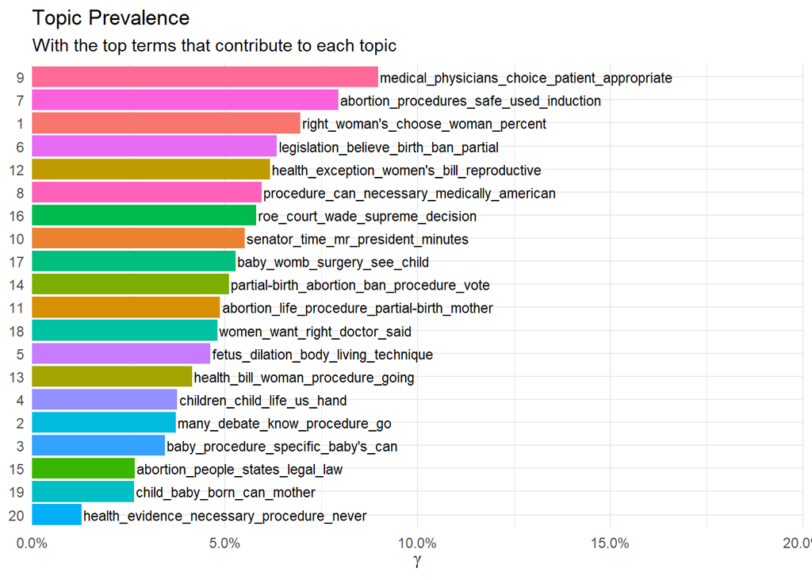

Also create a perspective plot visualizing the combination of two topics and discuss the results.

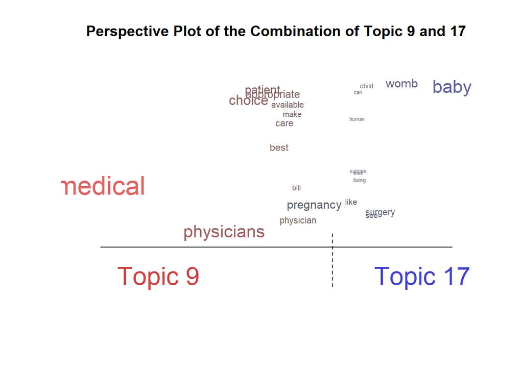

## Fit an stm with covariates

Refit your favorite stm model but this time include a covariant for party affiliation into the model (i.e. saying that party affiliation impacts topic prevalence).

```r
refit_stm_20 <- stm(~party,
    documents = para_stm$documents,
    vocab = para_stm$vocab,
    K = 20,
    data = para_stm$meta
    )
```

Once the model converged, estimate the effect that party affiliation has on the prevalence of two topics, i.e. are Democrats or Republicans more likely to speak about either of the topics. Create a plot of your estimated effects and discuss your results.

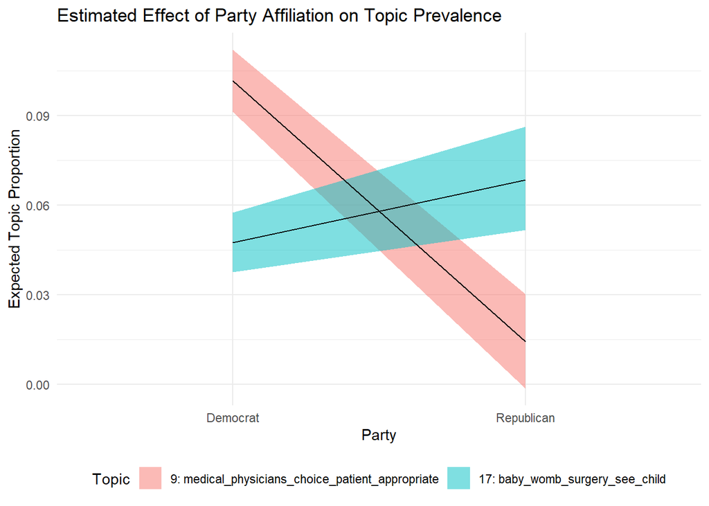

*Discussion:* As is illustrated in the figure above, party affiliation visibly affects topic prevalence. While Democrats are less likely (4.70%) to discuss topic 17, i.e. a position condemning partial-birth abortion, than Republicans (6.88 %), the difference between the parties in expected topic prevalence is much more pronounced in the expected topic prevalence of topic 9, which likely represents a pro-choice position for partial-birth abortion under medical reasons. While expected topic proportion for topic 9 is at 10.08 % for Democrat speakers in the corpus, it goes down to ca. 1.48 % for Republicans.

## Summarize

Summarize your findings across all tasks in a paragraph or two

*Summary:* In this assignment, I have performed text analysis on a corpus containing 23 transcriptions of the 2007 US Senate debate on so-called partial-birth abortion, a term that describes a medical procedure where fetuses are being removed from the uterus by dilating a pregnant woman’s cervix, then pulling the entire body out through the birth canal. This type of abortion is usually performed at a stage after the 20th pregnancy week. The term was first coined by the National Right to Life Committee (NRLC) and is considered a political, as the correct medical term is “dilation & extraction” (D&E). Late-stage pregnancy termination is a polarizing political issue that has been discussed in the context of the larger abortion debate, with the pro-choice, abortion-right movement on the one and the pro-life, anti-abortion movement on the other side.

Performing topic modeling on these 23 transcriptions first required to find the optimal number of topics, which can be found at $K$ = 20, where diagnostic plots have shown that held-out likelihood takes the highest value, residuals are low and the coherence-exclusivity trade-off is acceptable. While held-out likelihood is an indicator of goodness of fit of the model on previously unseen data, i.e. its ability to generate high-quality predictions on new texts, it has been shown that it’s not strongly, or even negatively, correlated with human judgment. Therefore, additionally obtaining semantic coherence and topic exclusivity diagnostics is crucial to selecting the optimal $K$ value for a model. The topic label output from the model with 20 topics shows that the issue can be approached from several perspectives, e.g. from a medical-technical viewpoint (e.g. topic 5: `fetus_dilation_body_living_technique`), from a legal stance (e.g. topic 16: `roe_court_wade_supreme_decision`), from a feminist angle (e.g. topic 1: `right_woman's_choose_woman_percent`) or from a normative-fundamentalist approach (e.g. topic 4: `children_child_life_us_hand`). Topic 10 (`senator_time_mr_president_minutes`) however holds little substantive meaning. This indicates that future analysis on this data set should involve more thorough data preparation and cleaning, e.g. by adding customized stop words.

However, taking a closer look at some of the most representative documents per topic shows that topic terms, alone, can only be indicative, but not entirely predictive of a speaker’s position on abortion. For example, topic 20 (`health_evidence_necessary_procedure_never`) would be assumed to support D&E abortions if available health data provides the necessary evidence, but a quote of the second-most representative document for that topic actually shows that the speaker claims available evidence would be biased and not sufficient to ever warrant the procedure.

Nevertheless, a perspective plot on two topics that I suspected represent well a pro-choice- and a pro-life-leaning debate illustrates that topic terms can indeed be used as an indicator: The two topics have very little terms in common and the two most important terms strongly favor the respective topic, i.e. they are farthest left and right on the x-axis of the plot.

Lastly, adding speakers’ party affiliation as a covariate to the topic model shows that party affiliation affects topic prevalence. When looking at estimated effects for topic 9 and 17, which have proven to be two fairly opposing topics by the perspective plot, we can see that Democrats are much more likely to speak about topic 9 than Republicans are. And while Democrats are less likely to speak about topic 17, the difference is less pronounced than for topic 9, showing that there probably are very little few Republicans who support D&E abortion, and a comparably higher share of Democrats who condemn it.